# Introduktion till *ggplot2*

Daniel Lindholm

Det finns flera olika sätt att plotta data med hjälp av R. Det finns dels ett inbyggt system som brukar kallas *base plot*, dels ett paket som heter *lattice*. Numera används kanske paketet *ggplot2* allra mest (gg står för grammar of graphics, som är ett system för datavisualisering som utvecklades av Leland Wilkinson).

Grundtanken är den att man utgår från data, där man specificerar vad som ska visualiseras. Sedan lägger man på ett eller flera lager av grafik. Det enklaste är väl att sätta igång. Låt oss använda det vid det här laget välkända iris-dataset:et.

```r
install.packages("ggplot2")
library(ggplot2)
data("iris")
```

## Scatter plot

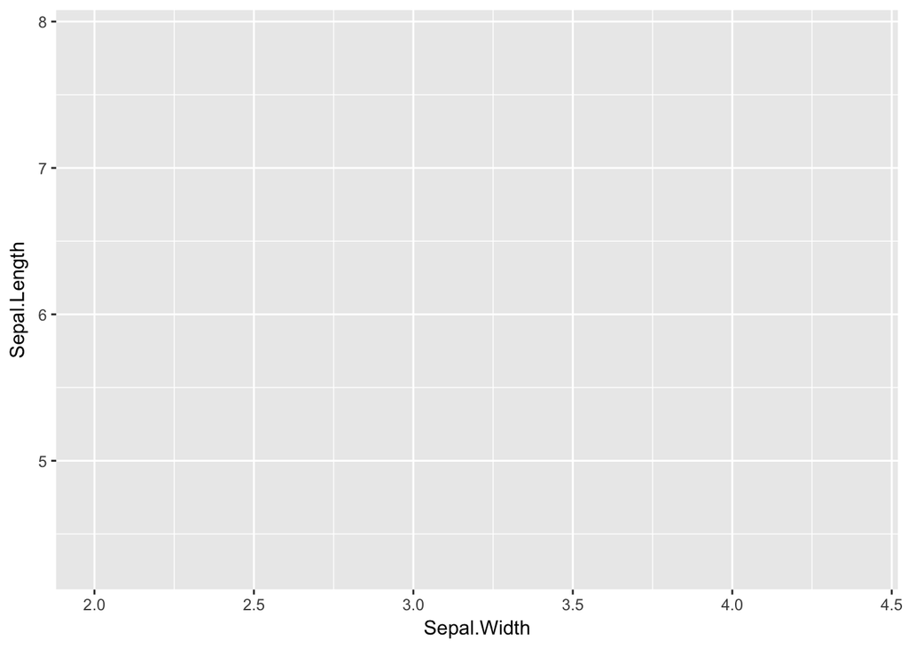

```r
ggplot(iris, aes(x = Sepal.Width, y = Sepal.Length))
```

Men vänta nu? Vi ser ju ingenting på plotten, bara axlarna! Vi behöver alltså lägga till ett lager för att specificera vilken typ av plot vi vill använda. Dessa lager kallas *geom*. I det här fallet vill vi lägga till punkter:

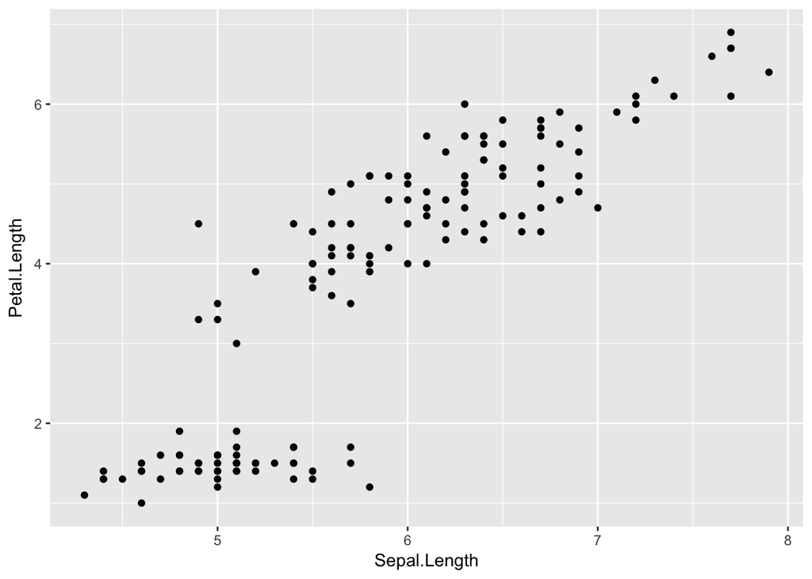

```r
ggplot(iris, aes(x = Sepal.Length, y = Petal.Length)) + geom_point()
```

Det tycks finnas ett samband. Vi kanske vill lägga till ett lager med en linjär regression? Då kan vi i tillägg till en *geom* till, i det här fallet *geom_smooth* där vi specificerar metoden *“lm”*. (Om man inte specificerar någon metod kommer loess användas):

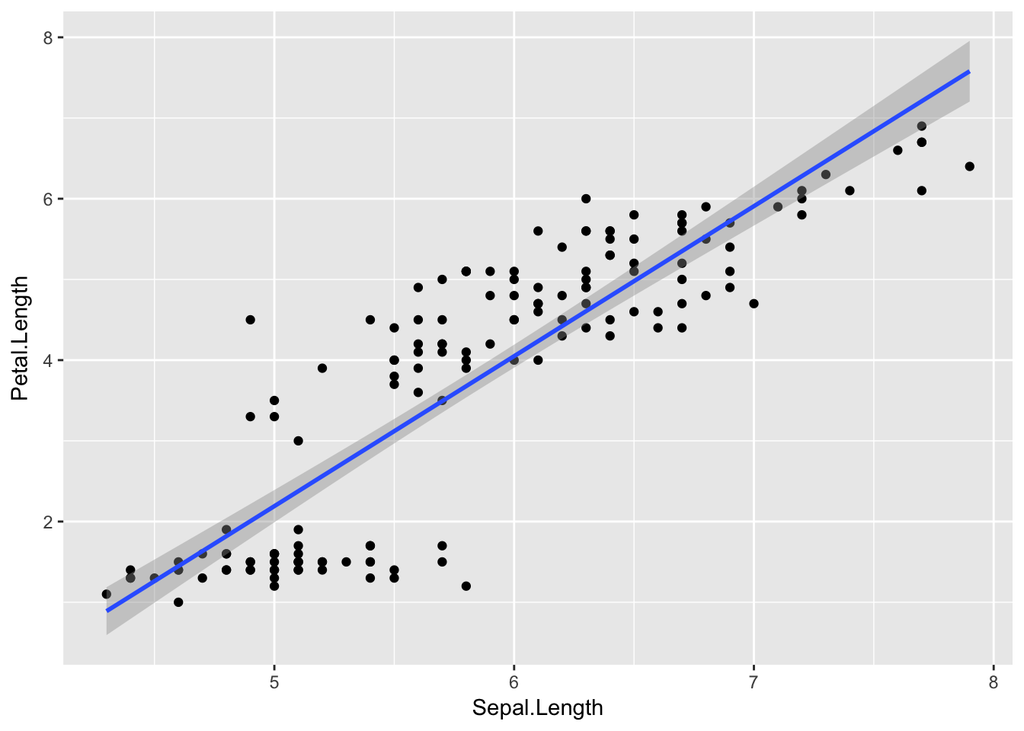

```r
ggplot(iris, aes(x = Sepal.Length, y = Petal.Length)) + geom_point() + geom_smooth(method = "lm")
```

Men ser det inte lite konstigt ut? Det tycks finnas en gruppering nere i vänstra hörnet. Som du kanske kommer ihåg handlade det här dataset:et om att klassificera olika typer av iris-blommor. Vi har ju använt skalorna *x* och *y*; låt oss använda en till, nämligen *färg* :

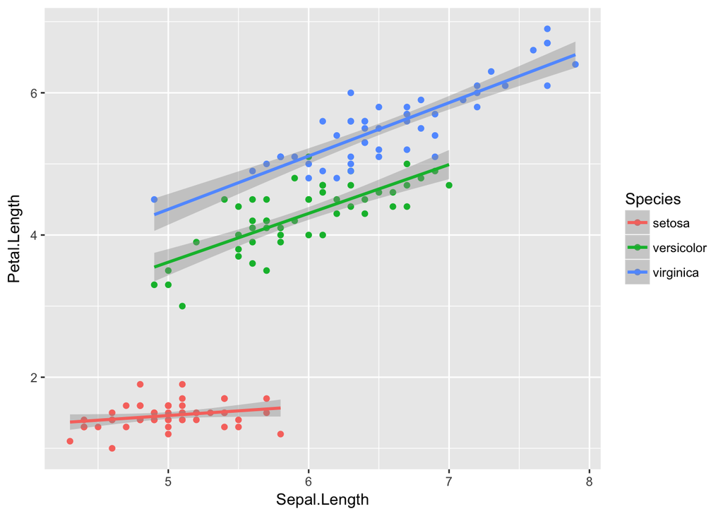

```r
ggplot(iris, aes(x = Sepal.Length, y = Petal.Length, color = Species)) +
  geom_point() +
  geom_smooth(method = "lm")
```

Här ser vi då att blommorna i nedre vänstra hörnet tillhörde species “setosa”. Observera att vi genom att lägga till färgskalan grupperade datapunkterna, men också de linjära modellerna.

## Boxplot

Låt oss också utforska hur vi kan göra box-plottar. Nu är vi intresserade av Sepal.Width, och hur den ser ut i de olika species. Vi vill alltså ha Sepal.Width på y-axeln och Species på x-axeln:

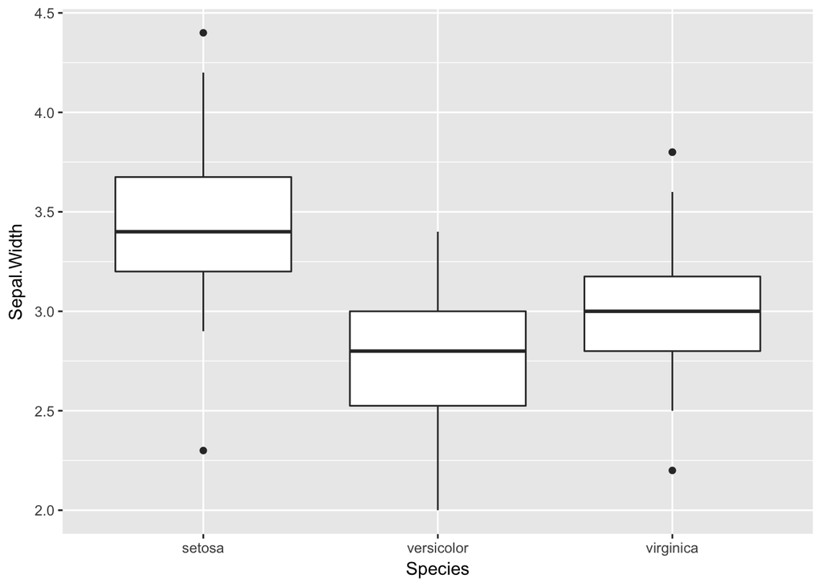

```r
ggplot(iris, aes(x = Species, y = Sepal.Width)) +
  geom_boxplot()
```

## Density plot

Vill vi undersöka distributionerna på ett annat sätt kan vi använda densitets-plottar:

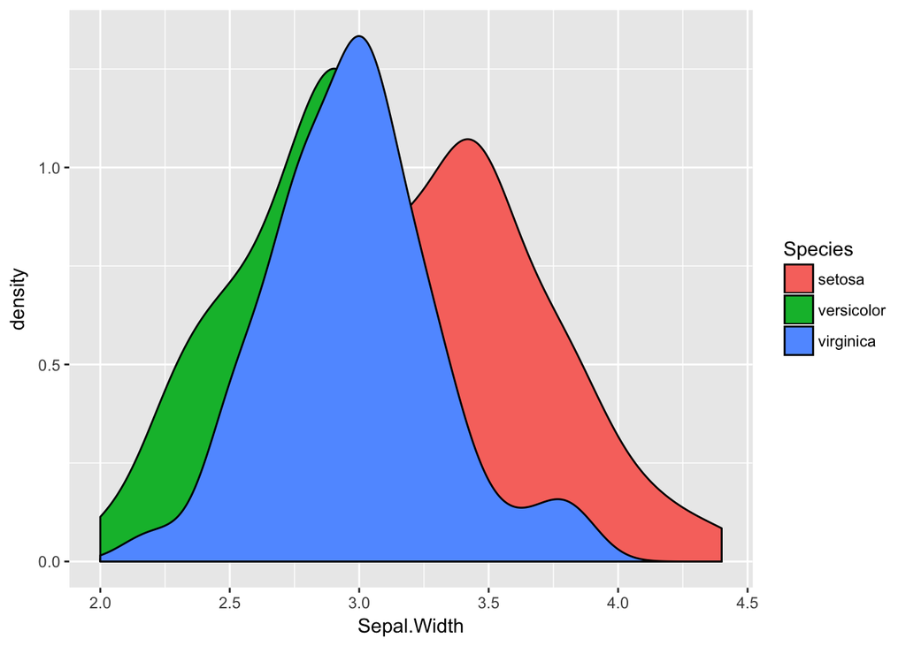

```r
ggplot(iris, aes(fill = Species, x = Sepal.Width)) +
  geom_density()
```

I det här fallet kommer ju Sepal.Width vara på x-axeln, densiteten på y-axeln, och vi delar upp data utifrån Species. Lägg märke till att vi specificerade *fill* snarare än *color* (det var fyllningen av densiteterna istället för linjerna vi ville färglägga). Det verkar ju intressant, men ytorna överlappar. Låt oss ange *alpha* för att komma till rätta med det. Alpha går från 0 till 1 där 1 är helt ogenomskinligt. Vi testar att göra plottarna lite genomskinliga genom att sätta alpha till 0.4:

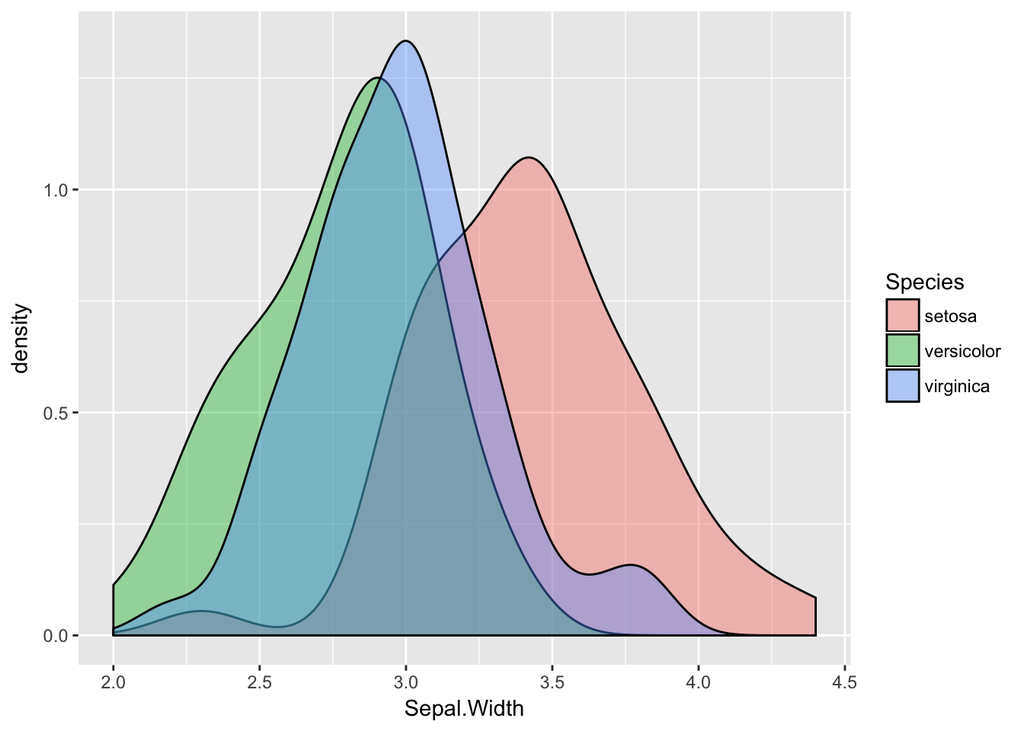

```r
ggplot(iris, aes(fill = Species, x = Sepal.Width)) +
  geom_density(alpha = 0.4)
```

## Tema

Vi kanske inte tycker att den grå bakgrunden är så trevlig. Det finns olika teman för plottarna (och det går att ändra alla detaljer i hur plotten ritas). Vi provar ett par! För smidighets skull sparar vi plotten i en variabel, *p*, och lägger bara till teman efter hand.

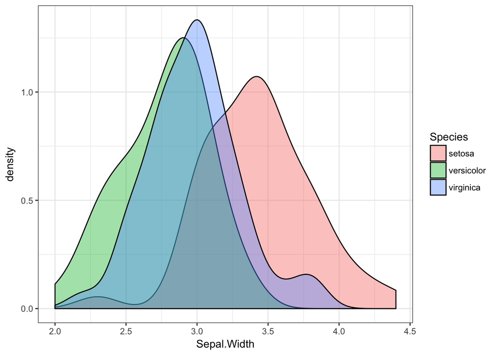

```r
p <- ggplot(iris, aes(fill = Species, x = Sepal.Width)) +
  geom_density(alpha = 0.4)

# Svart-vitt (alltså vad gäller bakgrund etc...)
p + theme_bw()
```

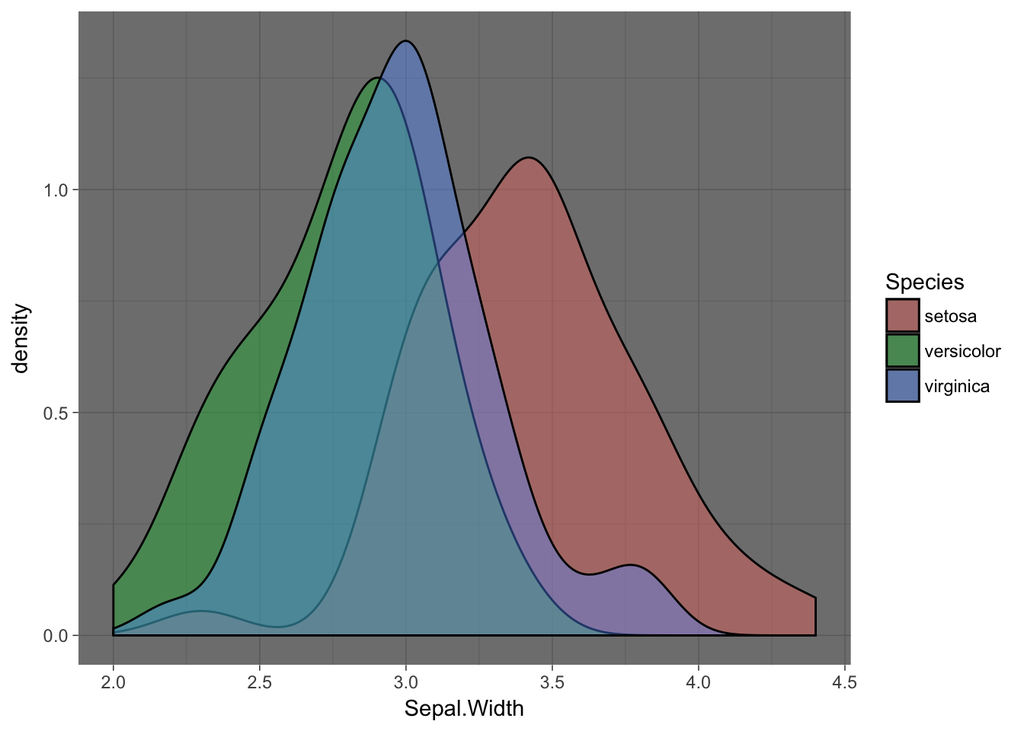

```r
# Mörkt
p + theme_dark()
```

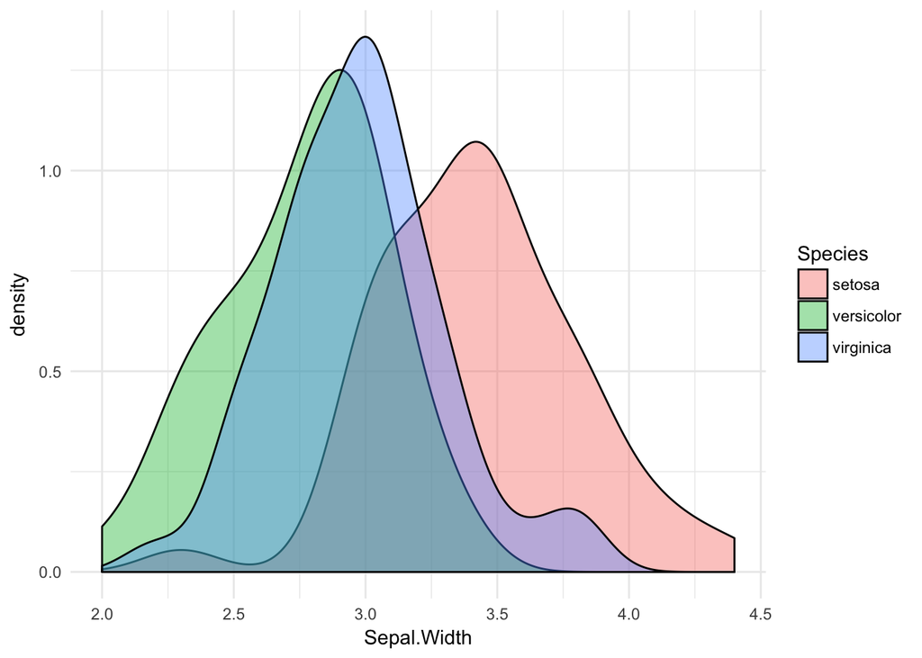

```r
# Minimalt
p + theme_minimal()
```

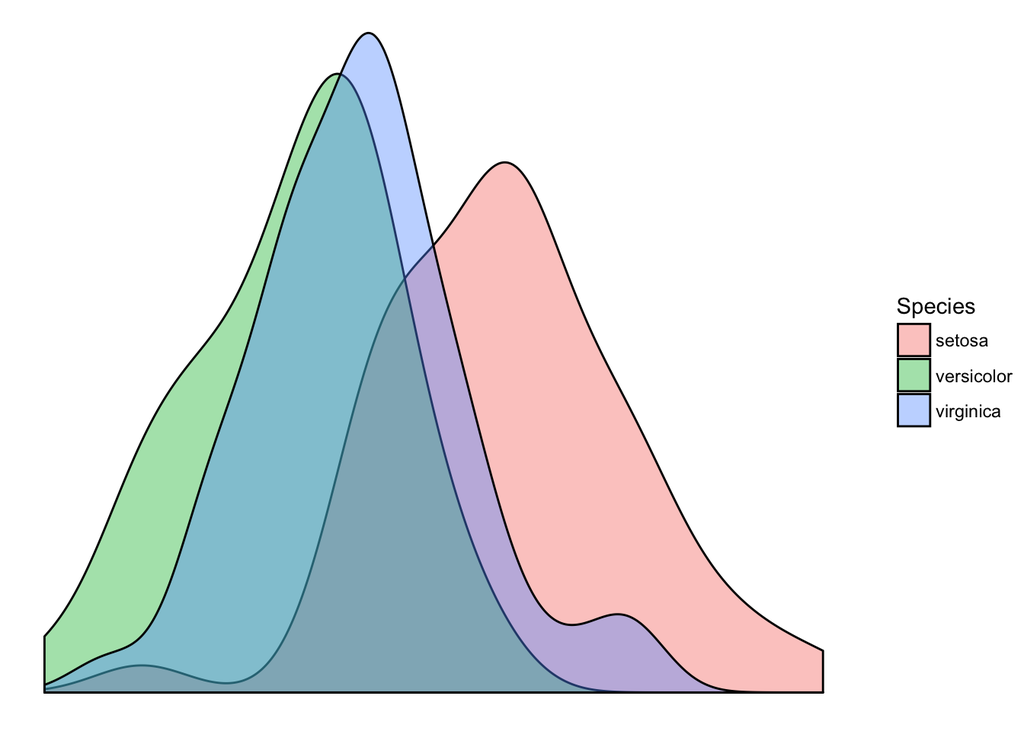

```r
# Helt utan linjer, axlar och dylikt
p + theme_void()
```

## Andra plot-typer

Det finns ett stort antal olika *geoms* att använda, vilka beskrivs i [ggplot2-dokumentationen](http://ggplot2.tidyverse.org/reference/). En lathund finns [här](https://www.rstudio.com/wp-content/uploads/2015/03/ggplot2-cheatsheet.pdf).

## Sammanfattning

I det här avsnittet har vi introducerat paketet *ggplot2*, och undersökt scatterplot, boxplot och density plot. Det finns i det närmaste oändliga möjligheter att skräddarsy plottarna utifrån vilka behov vi har. Utöver de plottyper som finns i paketet finns det *geoms* som andra användare har utformat för att lösa specifika visualiseringsproblem.